Exploring White Wine Samples by Michaela Wonacott

========================================================

# Initial Observations

That data will be exploring is about white wine samples from the Portuguese “Vinho Verde” wine. The samples went through various objective tests to determining their quality (output) based on sensory data.

# Univariate Plots Section

```
## [1] 4898   13
```

```
## 'data.frame':    4898 obs. of  13 variables:
##  $ X                   : int  1 2 3 4 5 6 7 8 9 10 ...
##  $ fixed.acidity       : num  7 6.3 8.1 7.2 7.2 8.1 6.2 7 6.3 8.1 ...
##  $ volatile.acidity    : num  0.27 0.3 0.28 0.23 0.23 0.28 0.32 0.27 0.3 0.22 ...
##  $ citric.acid         : num  0.36 0.34 0.4 0.32 0.32 0.4 0.16 0.36 0.34 0.43 ...
##  $ residual.sugar      : num  20.7 1.6 6.9 8.5 8.5 6.9 7 20.7 1.6 1.5 ...
##  $ chlorides           : num  0.045 0.049 0.05 0.058 0.058 0.05 0.045 0.045 0.049 0.044 ...
##  $ free.sulfur.dioxide : num  45 14 30 47 47 30 30 45 14 28 ...
##  $ total.sulfur.dioxide: num  170 132 97 186 186 97 136 170 132 129 ...
##  $ density             : num  1.001 0.994 0.995 0.996 0.996 ...
##  $ pH                  : num  3 3.3 3.26 3.19 3.19 3.26 3.18 3 3.3 3.22 ...
##  $ sulphates           : num  0.45 0.49 0.44 0.4 0.4 0.44 0.47 0.45 0.49 0.45 ...
##  $ alcohol             : num  8.8 9.5 10.1 9.9 9.9 10.1 9.6 8.8 9.5 11 ...
##  $ quality             : int  6 6 6 6 6 6 6 6 6 6 ...
```

```
##        X        fixed.acidity    volatile.acidity  citric.acid
##  Min.   :   1   Min.   : 3.800   Min.   :0.0800   Min.   :0.0000
##  1st Qu.:1225   1st Qu.: 6.300   1st Qu.:0.2100   1st Qu.:0.2700
##  Median :2450   Median : 6.800   Median :0.2600   Median :0.3200
##  Mean   :2450   Mean   : 6.855   Mean   :0.2782   Mean   :0.3342
##  3rd Qu.:3674   3rd Qu.: 7.300   3rd Qu.:0.3200   3rd Qu.:0.3900
##  Max.   :4898   Max.   :14.200   Max.   :1.1000   Max.   :1.6600
##  residual.sugar     chlorides       free.sulfur.dioxide total.sulfur.dioxide
##  Min.   : 0.600   Min.   :0.00900   Min.   :  2.00      Min.   :  9.0
##  1st Qu.: 1.700   1st Qu.:0.03600   1st Qu.: 23.00      1st Qu.:108.0
##  Median : 5.200   Median :0.04300   Median : 34.00      Median :134.0
##  Mean   : 6.391   Mean   :0.04577   Mean   : 35.31      Mean   :138.4
##  3rd Qu.: 9.900   3rd Qu.:0.05000   3rd Qu.: 46.00      3rd Qu.:167.0
##  Max.   :65.800   Max.   :0.34600   Max.   :289.00      Max.   :440.0
##     density             pH          sulphates         alcohol
##  Min.   :0.9871   Min.   :2.720   Min.   :0.2200   Min.   : 8.00
##  1st Qu.:0.9917   1st Qu.:3.090   1st Qu.:0.4100   1st Qu.: 9.50
##  Median :0.9937   Median :3.180   Median :0.4700   Median :10.40
##  Mean   :0.9940   Mean   :3.188   Mean   :0.4898   Mean   :10.51
##  3rd Qu.:0.9961   3rd Qu.:3.280   3rd Qu.:0.5500   3rd Qu.:11.40
##  Max.   :1.0390   Max.   :3.820   Max.   :1.0800   Max.   :14.20
##     quality
##  Min.   :3.000
##  1st Qu.:5.000
##  Median :6.000
##  Mean   :5.878
##  3rd Qu.:6.000
##  Max.   :9.000
```

The initial summaries and insights of the data reveals that the dataset consists of 13 variables, with 4,898 observations. Quality is the output variable. X is for the identification of each white wine sample that was rated. This leaves 11 independent variables (or attributes) that impact the quality of the wine. The attributes are fixed acidity, volatile acidity, citric acid, residual sugar, chlorides, free sulfur dioxide, total sulfur dioxide, density,pH, sulphates, and alcohol.

Since quality is the output of all the attributes, I decided to examine it first.

### Quality

Quality is currently a integer value. However, it is better represented as a categorical variable since it is a rating. To convert quality to a categorical variable, I decided to factor quality.

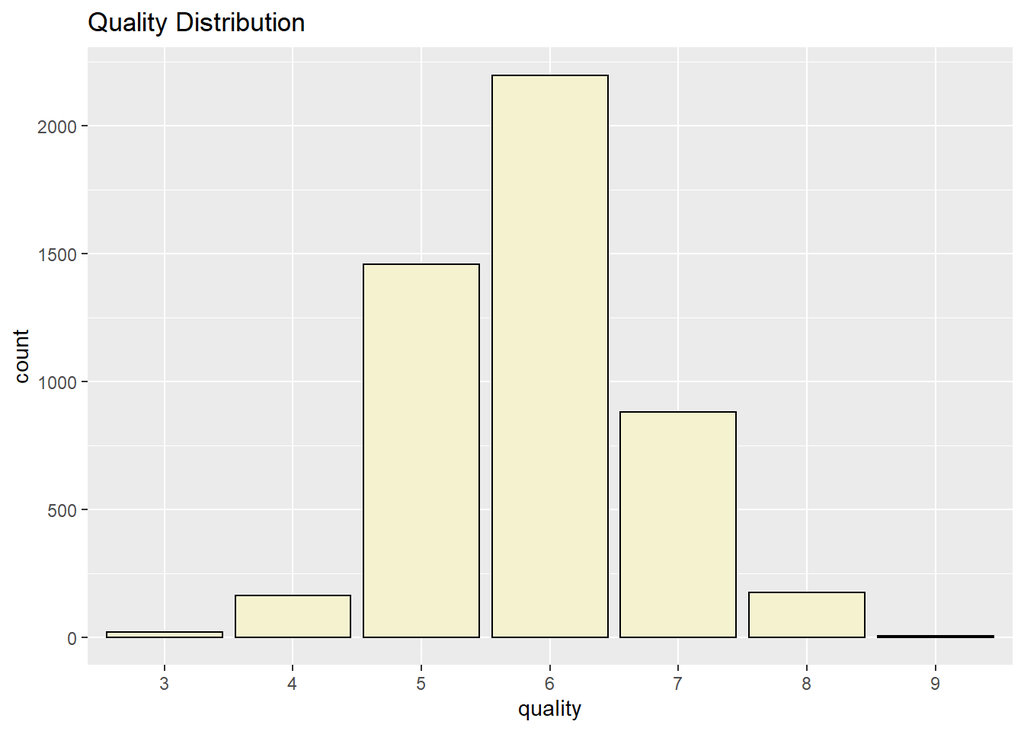

```
##    Min. 1st Qu.  Median    Mean 3rd Qu.    Max.
##   3.000   5.000   6.000   5.878   6.000   9.000
```

Quality rating has a range between 0 and 10. Most white wines have a rating between 5-7, with the majority of wines rated 6. The lowest rating of wine for this sample is 3 and the highest rated wine is 9. There were no wines with a rating 1, 2, or 10.

This leads me to believe there are few wines the rank low or high. This made me curious. Since the majority of white wines are clustered between 5-7 rating, are there attributes that make a wine quality a 6. Is there a distinct attribute that increases or decreases a wines quality rating? To answer these questions and to gain a better understanding of each variable, I decided to examine each attribute separately.

### Fixed Acidity

[output not shown]

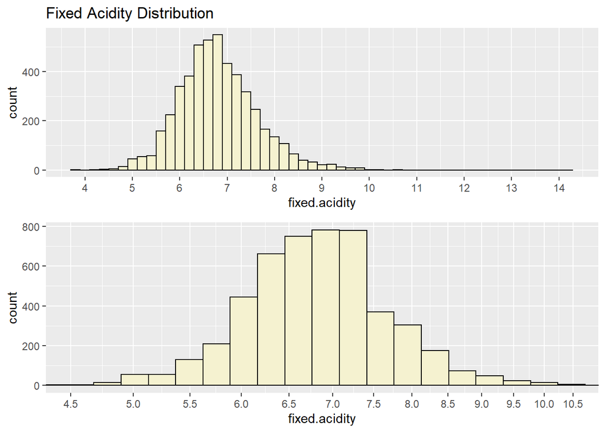

```
##    Min. 1st Qu.  Median    Mean 3rd Qu.    Max.
##   3.800   6.300   6.800   6.855   7.300  14.200
```

Most wines had a fixed acidity level between 6.3$g/dm^3$ and 7.3$g/dm^3$: median6.8$g/dm^3$ and mean 6.85$g/dm^3$.

### Volatile Acidity

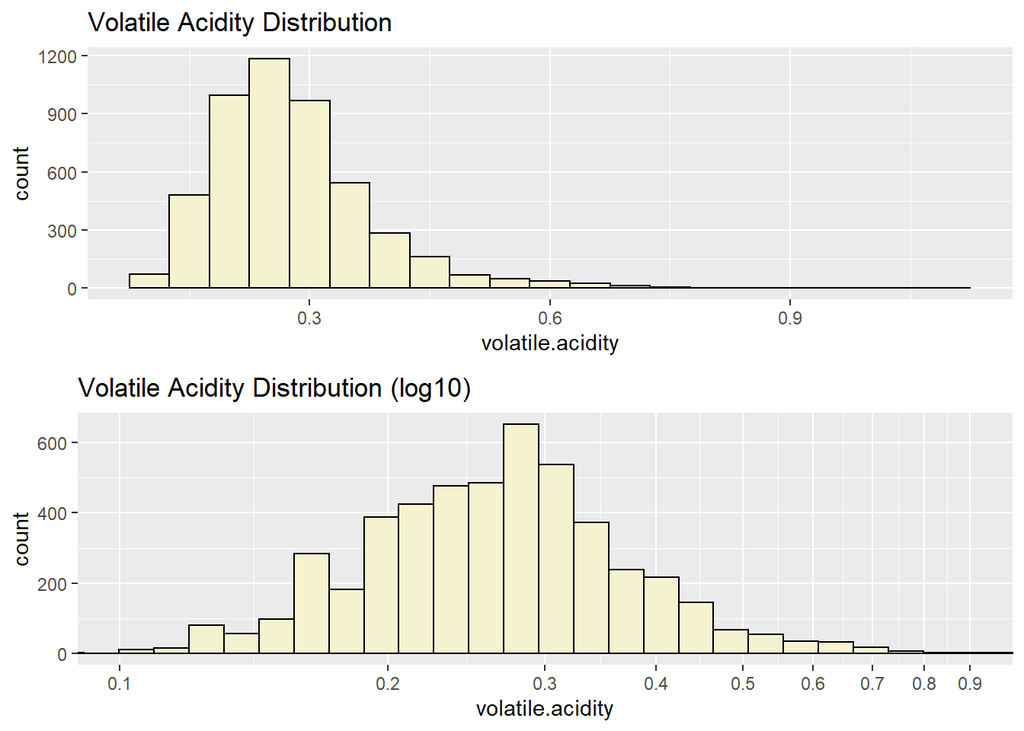

```
##    Min. 1st Qu.  Median    Mean 3rd Qu.    Max.
##  0.0800  0.2100  0.2600  0.2782  0.3200  1.1000
```

Most wines had a volatile acidity level between 0.21$g/dm^3$ and 0.32$g/dm^3$: median 0.26$g/dm^3$ and mean 0.27$g/dm^3$.

Volatile acidity mostly follows a normal distribution that is somewhat skewed to the right due to long tail data. Because of the long tail data, I transformed volatile acidity by log10.

### Citric Acid

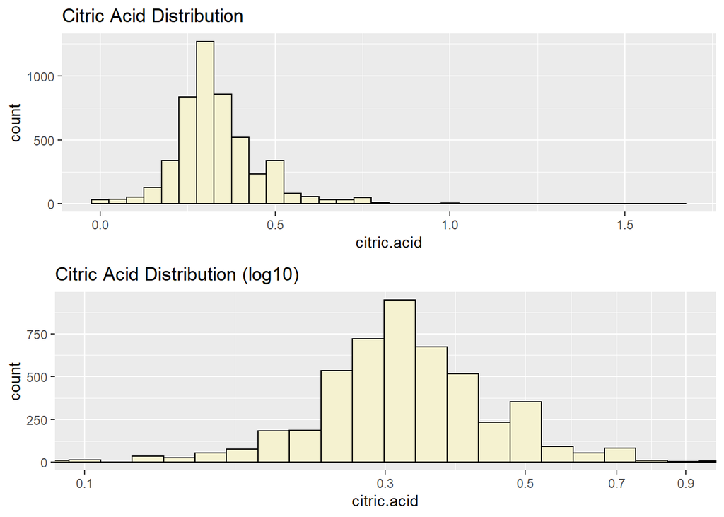

```
##    Min. 1st Qu.  Median    Mean 3rd Qu.    Max.
##  0.0000  0.2700  0.3200  0.3342  0.3900  1.6600
```

Most wines had a citric acid level between 0.27$g/dm^3$ and 0.39$g/dm^3$: median 0.32$g/dm^3$ and mean 0.3342$g/dm^3$.

Citric acid mostly follows a normal distribution that is somewhat skewed to the right due to long tail data. Because of the long tail data, I transformed citric acid by log10. There is a sudden spike in wines with a citric acid level around 0.5 $g/dm^3$.

### Residual Sugar

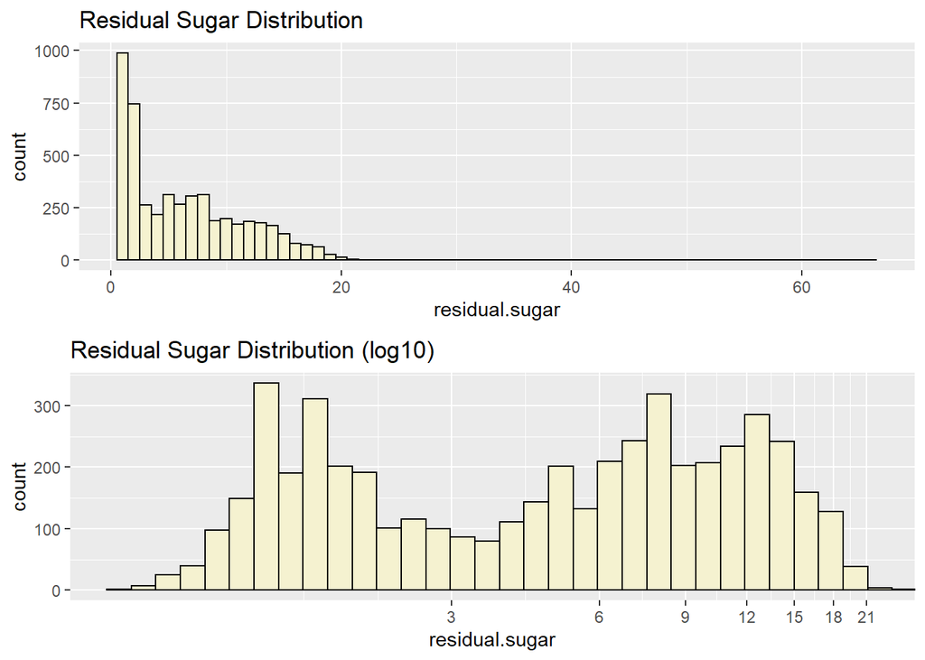

```
##    Min. 1st Qu.  Median    Mean 3rd Qu.    Max.
##   0.600   1.700   5.200   6.391   9.900  65.800
```

Most wines had a residual sugar level between 1.7$g/dm^3$ and 9.9$g/dm^3$: median 5.2$g/dm^3$ and mean 6.391$g/dm^3$.

Residual sugar somewhat follows a bimodel distribution with a significant amount of long tail data. Because of the long tail data, I transformed residual sugar by log10.

### Chlorides

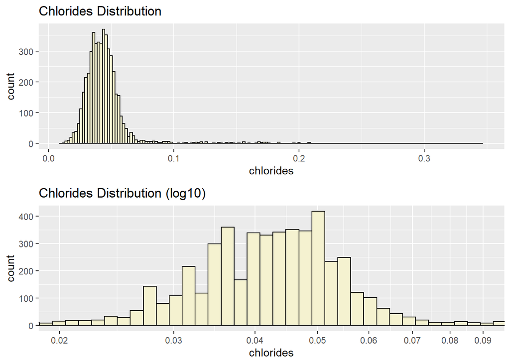

```
##    Min. 1st Qu.  Median    Mean 3rd Qu.    Max.
## 0.00900 0.03600 0.04300 0.04577 0.05000 0.34600
```

Most wines had a chloride level between 0.036$g/dm^3$ and 0.05$g/dm^3$: median 0.043$g/dm^3$ and mean 0.04577$g/dm^3$.

Chlorides mostly follows a normal distribution with a significant amount of long tail data. Because of the long tail data, I transformed chlorides by log10.

### Free Sulfur Dioxide

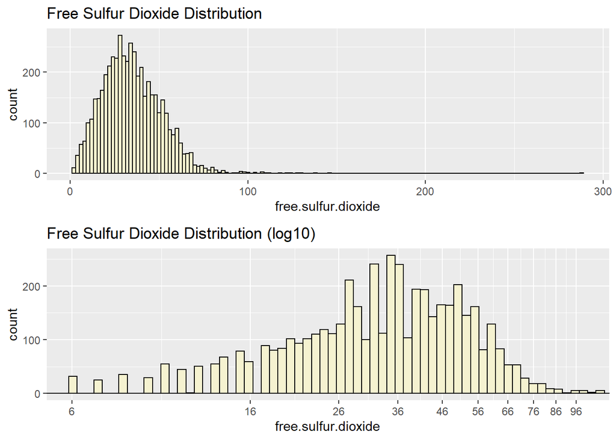

```
##    Min. 1st Qu.  Median    Mean 3rd Qu.    Max.
##    2.00   23.00   34.00   35.31   46.00  289.00
```

Most wines had a free sulfur dioxide level between 23$mg/dm^3$ and 46$mg/dm^3$: median 34$mg/dm^3$ and mean 35.31$mg/dm^3$.

Free sulfur dioxide mostly follows a slightly positively skewed distribution with a significant amount of long tail data. Because of the long tail data, I transformed free sulfur dioxide by log10.

### Total Sulfur Dioxide

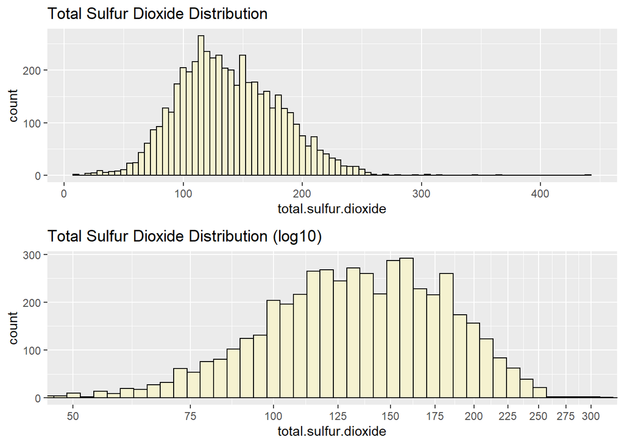

```
##    Min. 1st Qu.  Median    Mean 3rd Qu.    Max.
##     9.0   108.0   134.0   138.4   167.0   440.0
```

Most wines had a total sulfur dioxide level between 108$mg/dm^3$ and 167$mg/dm^3$: median 134$mg/dm^3$ and mean 138.4$mg/dm^3$.

Total sulfur dioxide mostly follows a slightly positively skewed distribution with a good amount of long tail data. Because of the long tail data, I transformed total sulfur dioxide by log10.

### Density

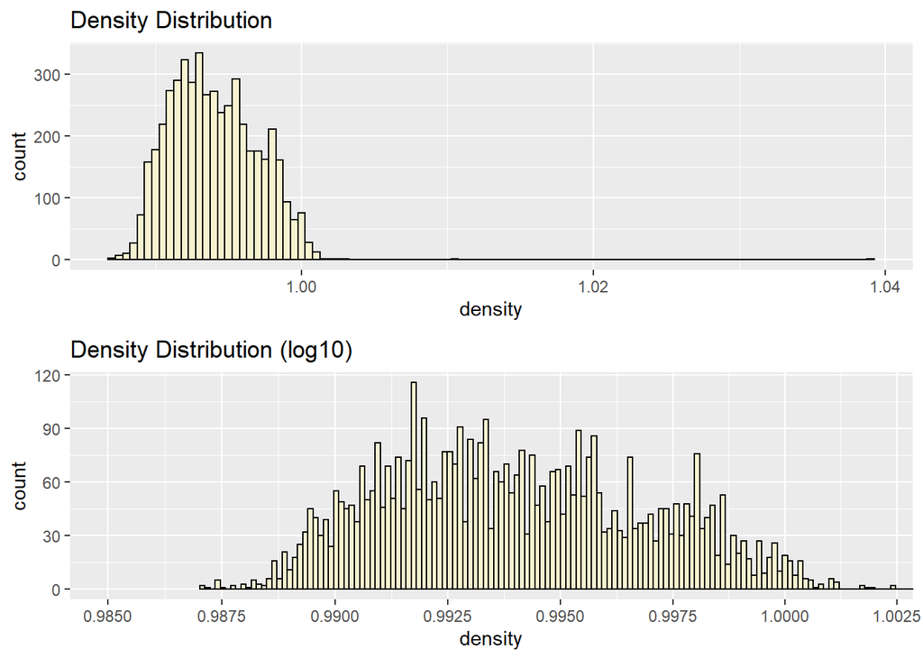

```
##    Min. 1st Qu.  Median    Mean 3rd Qu.    Max.
##  0.9871  0.9917  0.9937  0.9940  0.9961  1.0390
```

Most wines had a density level between 0.9917$g/cm^3$ and 0.9961$g/cm^3$: median 0.9937$g/cm^3$ and mean 0.994$g/cm^3$.

Density mostly follows a somewhat normal distribution with a significant amount of long tail data. Because of the long tail data, I transformed density by log10.

### pH

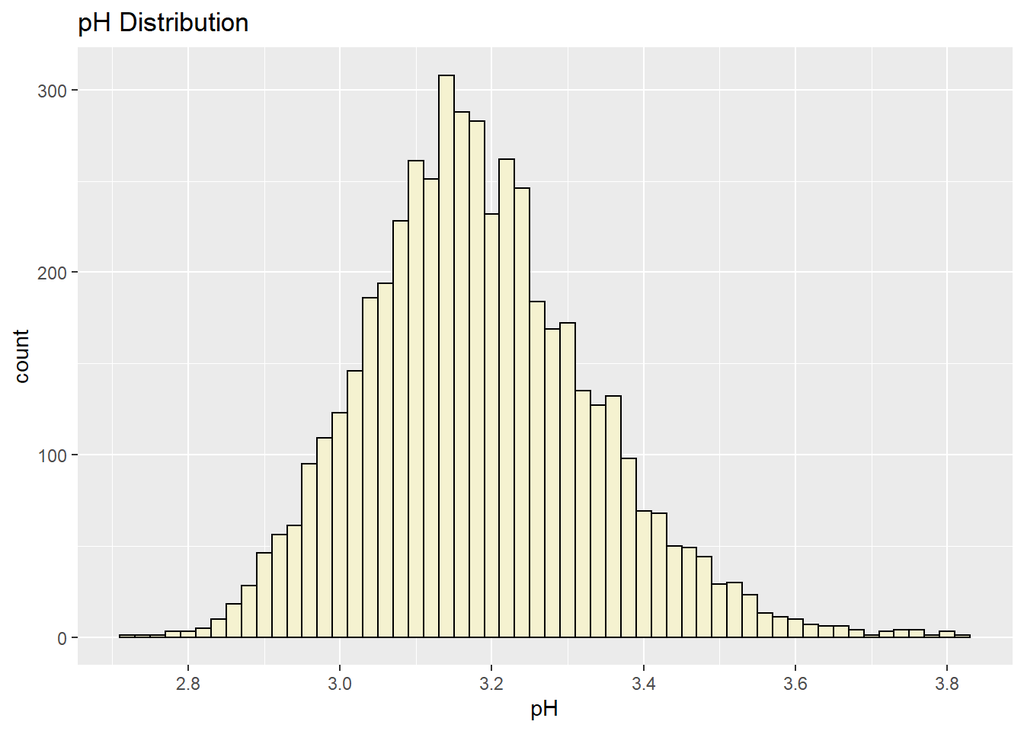

```
##    Min. 1st Qu.  Median    Mean 3rd Qu.    Max.
##   2.720   3.090   3.180   3.188   3.280   3.820
```

Most wines had a pH level between 3.09 and 3.28: median 3.18 and mean 3.188.

pH mostly follows a somewhat normal distribution. The graph has outliers reaching a max of 3.82.

### Sulphates

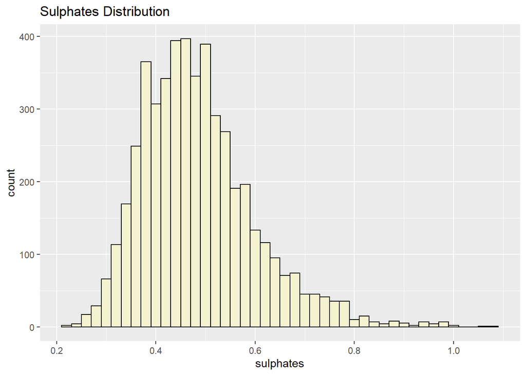

```
##    Min. 1st Qu.  Median    Mean 3rd Qu.    Max.
##  0.2200  0.4100  0.4700  0.4898  0.5500  1.0800
```

Most wines had a sulphate level between 0.41$g/dm3$ and 0.55$g/dm3$: median 0.47$g/dm3$ and mean 0.48$g/dm3$.

Sulphate follows a slightly skewed normal distribution. The graph has outliers reaching a max of 1.08$g/dm3$.

### Alcohol

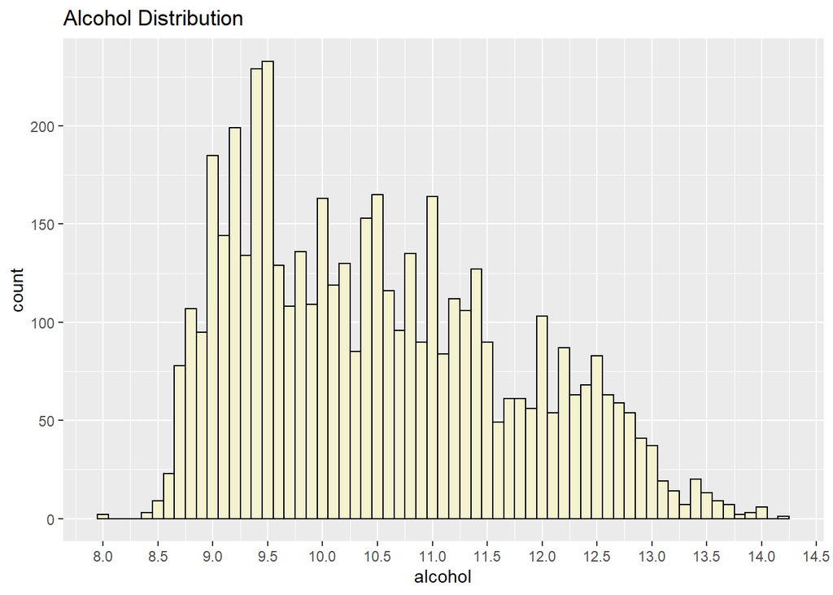

```
##    Min. 1st Qu.  Median    Mean 3rd Qu.    Max.
##    8.00    9.50   10.40   10.51   11.40   14.20
```

Most wines had an alcohol (% by volume) level between 9.5 and 11.4: median 10.4 and mean 10.51.

## Adjustments Insights from Attributes (Univariate Plots)

To have a better understanding of the data for each variable, I decided that I need to examine the bulk of my data when extreme outlines and anomalies were present. To do this, I transformed the x-axis by log10. The variables I transformed by log10 were: * fixed acidity * volatile acidity * citric acid * residual sugar * chlorides * free sulfur dioxide * total sulfur dioxide * density

Overall, most attributes follow a normal distribution. The few that did not are residual sugar, density, and alcohol. Notably, a majority of wines has a small amount of sugar. Density was approaching a uniform distribution. Alcohol having seemingly randomly spikes as amount of alcohol by volume increases.

# Univariate Analysis

### What is/are the main feature(s) of interest in your dataset?

The main feature is the quality rating of each white wine in the dataset.

investigation into your feature(s) of interest?

Using the sensory data features (input variables) will help determine which feature impacts the main feature, quality.

### Did you create any new variables from existing variables in the dataset?

The new variables I created were to separate variables who I need to two plots to display the data accurately.

### Of the features you investigated, were there any unusual distributions?

Did you perform any operations on the data to tidy, adjust, or change the form  
of the data? If so, why did you do this?

There were some skewed distributions and many had long tail data. The only changes I made was log10 transformations some of the variables’ long tail data. Besides that, it is a tidy data set and I saw no need for any other changes.

# Bivariate Plots Section

First task was to determine which variables correlate with quality.I did a Spearman rank correlation tests that compared quality to all attributes since quality is better represented as a degree of association.

Next, I did a Pearson r correlation test to get an overall sense of what attributes might correlate with other attributes.

## Determining Correlation Between Attributes and Quality

```
##                       [,1]
## fixed.acidity        -0.08
## volatile.acidity     -0.20
## citric.acid           0.02
## residual.sugar       -0.08
## chlorides            -0.31
## free.sulfur.dioxide   0.02
## total.sulfur.dioxide -0.20
## density              -0.35
## pH                    0.11
## sulphates             0.03
## alcohol               0.44
```

Because quality is the main feature, I will look at each meaningful (correlation greater than 0.3 or less than -0.3) variable with quality.

Attributes with a Meaningful Correlations with Quality: * chlorides (-0.31) * density (-0.35) * alcohol (0.44)

## Meaningful Correlations with Quality

### Quality vs Chlorides

```
##
##  Spearman's rank correlation rho
##
## data:  whitewine$quality and whitewine$chlorides
## S = 2.5743e+10, p-value < 2.2e-16
## alternative hypothesis: true rho is not equal to 0
## sample estimates:
##        rho
## -0.3144885
```

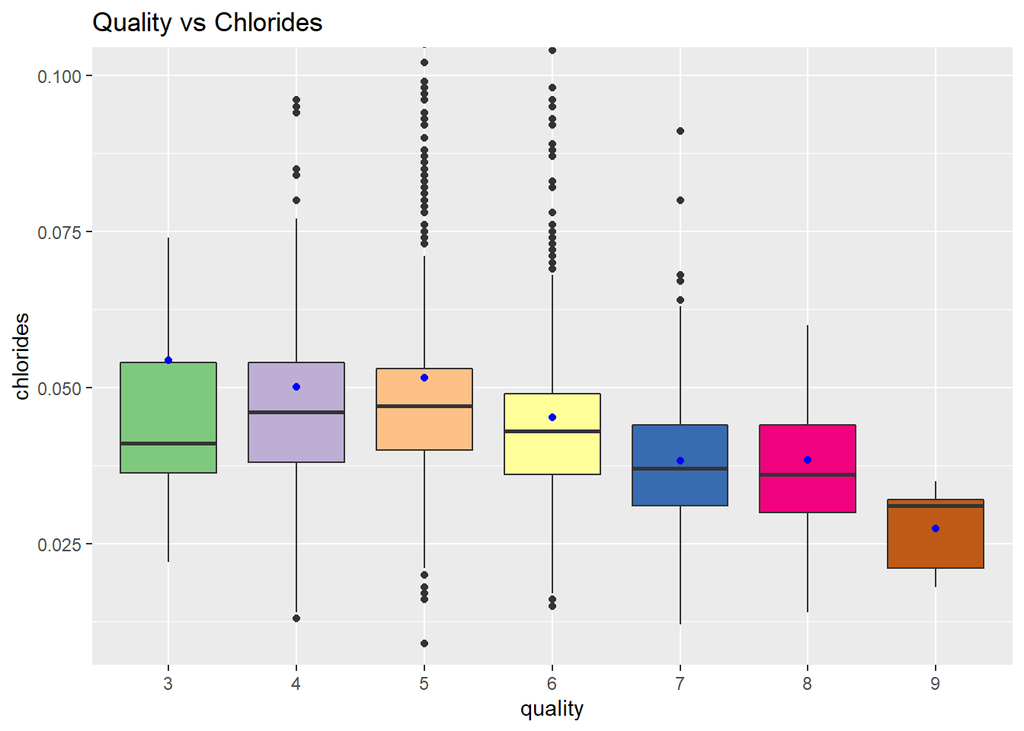

From the plot, we can see that there is a slight negative trend with chlorides and quality. However, this does not seem to have a great impact on the quality rating overall.

### Quality vs Density

```
##
##  Pearson's product-moment correlation
##
## data:  whitewine$quality and whitewine$density
## t = -22.581, df = 4896, p-value < 2.2e-16
## alternative hypothesis: true correlation is not equal to 0
## 95 percent confidence interval:
##  -0.3322718 -0.2815385
## sample estimates:
##        cor
## -0.3071233
```

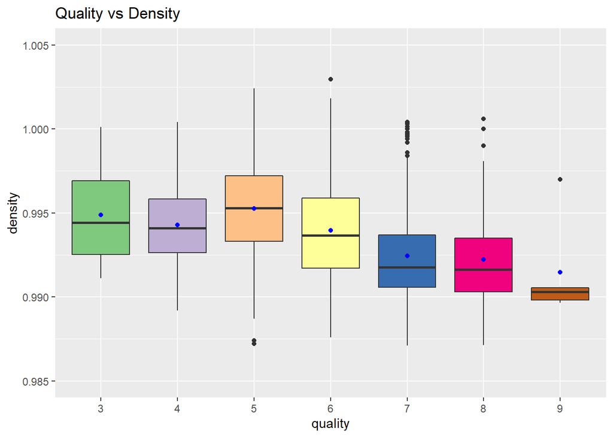

From the plot, we can see that there is a small negative trend with density and quality. However, this does not seem to have a great impact on the quality rating overall.

### Quality vs Alcohol

```
##
##  Pearson's product-moment correlation
##
## data:  whitewine$quality and whitewine$alcohol
## t = 33.858, df = 4896, p-value < 2.2e-16
## alternative hypothesis: true correlation is not equal to 0
## 95 percent confidence interval:
##  0.4126015 0.4579941
## sample estimates:
##       cor
## 0.4355747
```

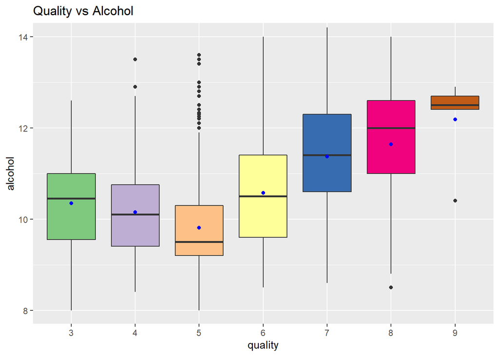

## Determining Correlation of Other Features (Excluding Quality)

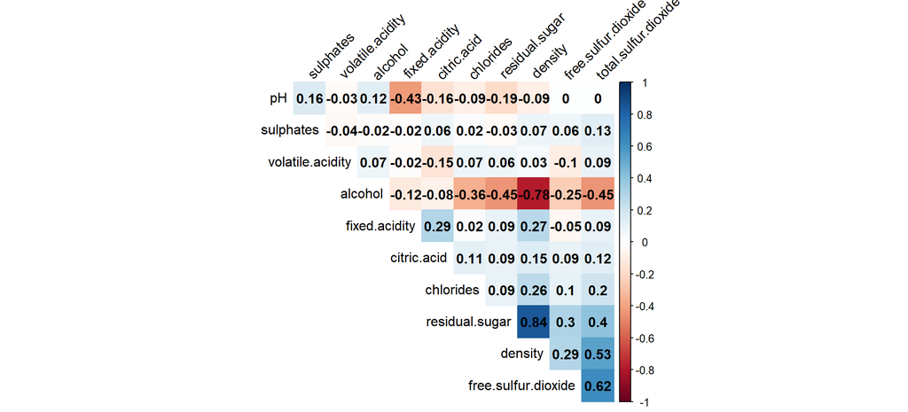

```
##                      fixed.acidity volatile.acidity citric.acid residual.sugar
## fixed.acidity                 1.00            -0.02        0.29           0.09
## volatile.acidity             -0.02             1.00       -0.15           0.06
## citric.acid                   0.29            -0.15        1.00           0.09
## residual.sugar                0.09             0.06        0.09           1.00
## chlorides                     0.02             0.07        0.11           0.09
## free.sulfur.dioxide          -0.05            -0.10        0.09           0.30
## total.sulfur.dioxide          0.09             0.09        0.12           0.40
## density                       0.27             0.03        0.15           0.84
## pH                           -0.43            -0.03       -0.16          -0.19
## sulphates                    -0.02            -0.04        0.06          -0.03
## alcohol                      -0.12             0.07       -0.08          -0.45
##                      chlorides free.sulfur.dioxide total.sulfur.dioxide density
## fixed.acidity             0.02               -0.05                 0.09    0.27
## volatile.acidity          0.07               -0.10                 0.09    0.03
## citric.acid               0.11                0.09                 0.12    0.15
## residual.sugar            0.09                0.30                 0.40    0.84
## chlorides                 1.00                0.10                 0.20    0.26
## free.sulfur.dioxide       0.10                1.00                 0.62    0.29
## total.sulfur.dioxide      0.20                0.62                 1.00    0.53
## density                   0.26                0.29                 0.53    1.00
## pH                       -0.09                0.00                 0.00   -0.09
## sulphates                 0.02                0.06                 0.13    0.07
## alcohol                  -0.36               -0.25                -0.45   -0.78
##                         pH sulphates alcohol
## fixed.acidity        -0.43     -0.02   -0.12
## volatile.acidity     -0.03     -0.04    0.07
## citric.acid          -0.16      0.06   -0.08
## residual.sugar       -0.19     -0.03   -0.45
## chlorides            -0.09      0.02   -0.36
## free.sulfur.dioxide   0.00      0.06   -0.25
## total.sulfur.dioxide  0.00      0.13   -0.45
## density              -0.09      0.07   -0.78
## pH                    1.00      0.16    0.12
## sulphates             0.16      1.00   -0.02
## alcohol               0.12     -0.02    1.00
```

[output not shown]

I decided to focus on other features with a strong correlation (correlation equal to or greater than 0.7 or, equal to or less than -0.7).

# Strongly Correlated Attributes

### Residual Sugar vs Density

```
##
##  Pearson's product-moment correlation
##
## data:  whitewine$density and whitewine$residual.sugar
## t = 107.87, df = 4896, p-value < 2.2e-16
## alternative hypothesis: true correlation is not equal to 0
## 95 percent confidence interval:
##  0.8304732 0.8470698
## sample estimates:
##       cor
## 0.8389665
```

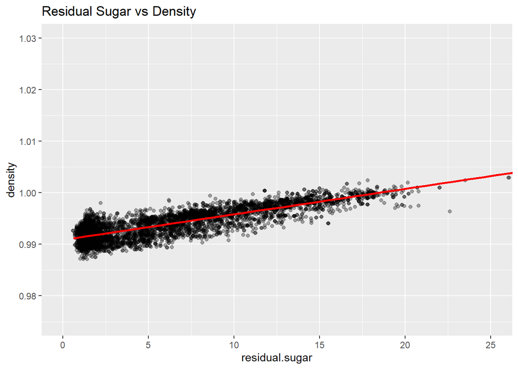

Visualization proving strong positive correlation with residual sugar and density.Though residual sugar and density have a high correlation. This can be explained that by adding more sugar in a ligued, its mass increases, therfore incresing its density.

### Alcohol vs Density

```
##
##  Pearson's product-moment correlation
##
## data:  whitewine$density and whitewine$alcohol
## t = -87.255, df = 4896, p-value < 2.2e-16
## alternative hypothesis: true correlation is not equal to 0
## 95 percent confidence interval:
##  -0.7908646 -0.7689315
## sample estimates:
##        cor
## -0.7801376
```

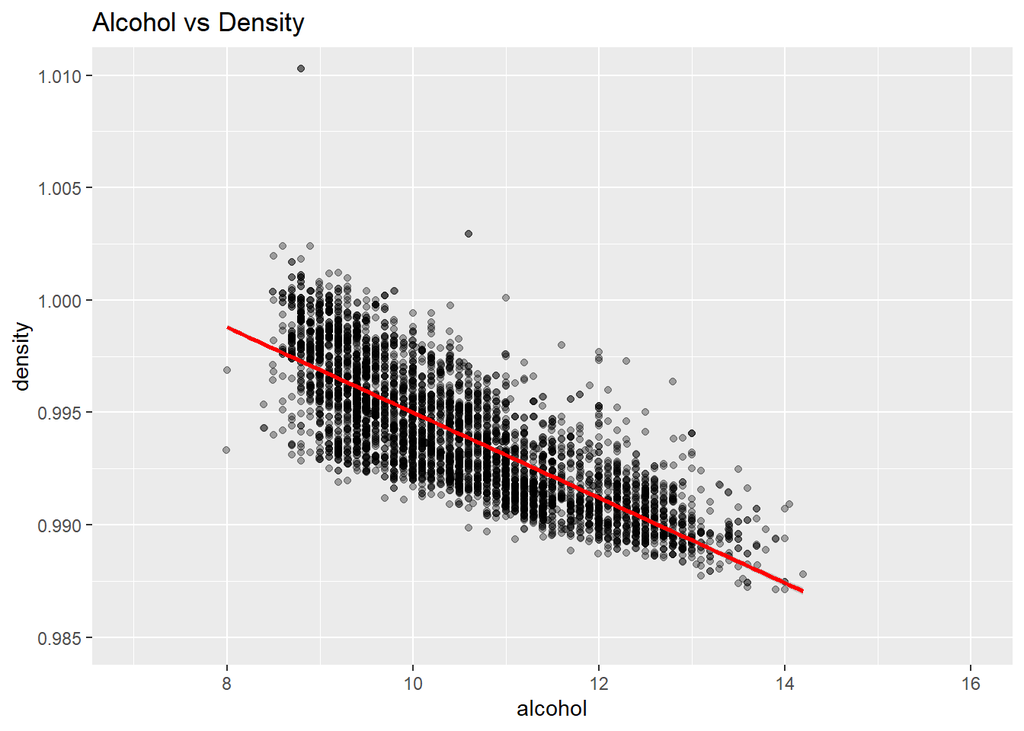

Visualization proving strong negative correlation with alcohol and density.

```
##
##  Pearson's product-moment correlation
##
## data:  whitewine$free.sulfur.dioxide and whitewine$total.sulfur.dioxide
## t = 54.645, df = 4896, p-value < 2.2e-16
## alternative hypothesis: true correlation is not equal to 0
## 95 percent confidence interval:
##  0.5977994 0.6326026
## sample estimates:
##      cor
## 0.615501
```

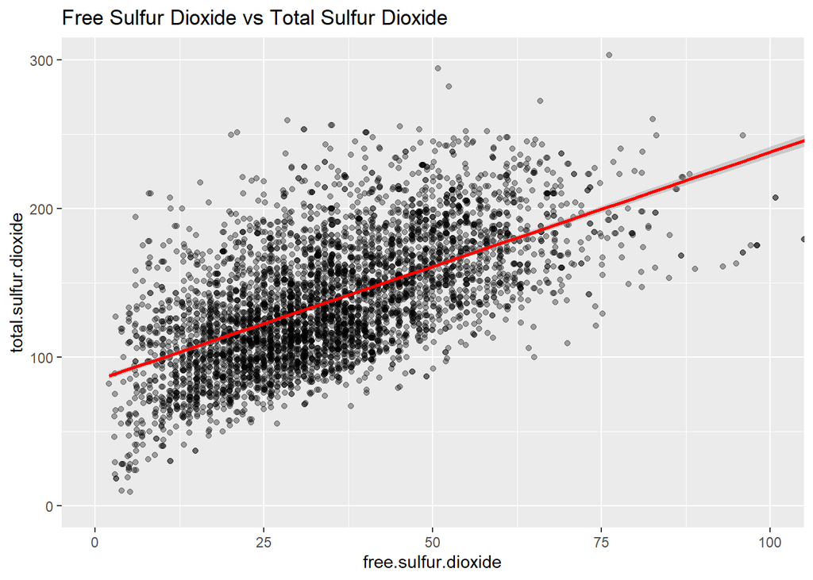

# Bivariate Analysis

investigation. How did the feature(s) of interest vary with other features in  
the dataset?

(not the main feature(s) of interest)?

### What was the strongest relationship you found?

The strongest relationship was between residual sugar and density. Density and residual sugar had a strongly positive correlation. This makes sense since a greater amount of sugar would increase the mass of the wine, leading to a grater density.

# Multivariate Plots Section

### Alcohol vs Density by Quality

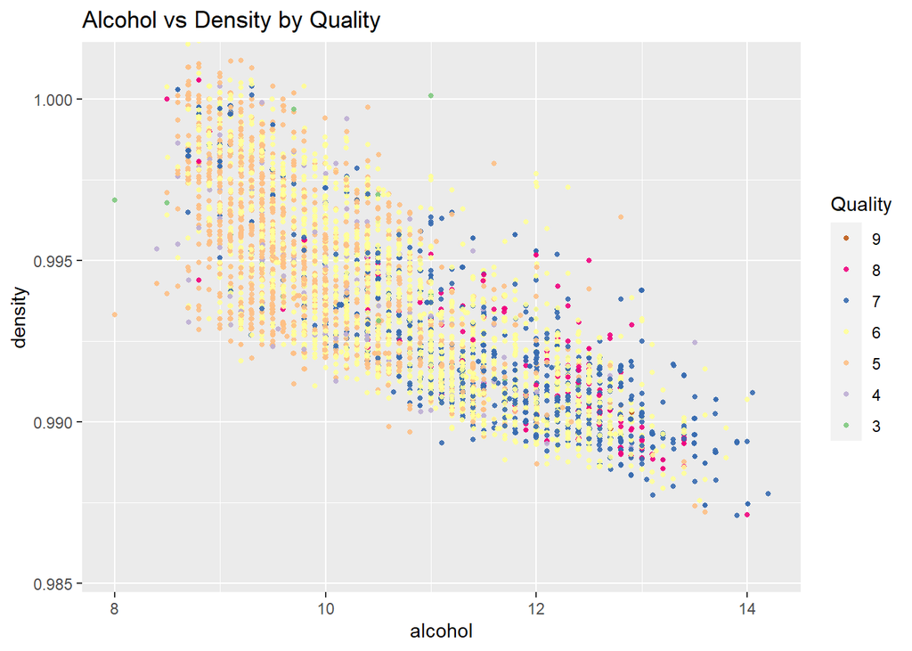

Visualization proving that despite density’s negative effect on quality rating, increasing alcohol levels impact can ease density’s impact.

### Alcohol vs Residual Sugar by Quality

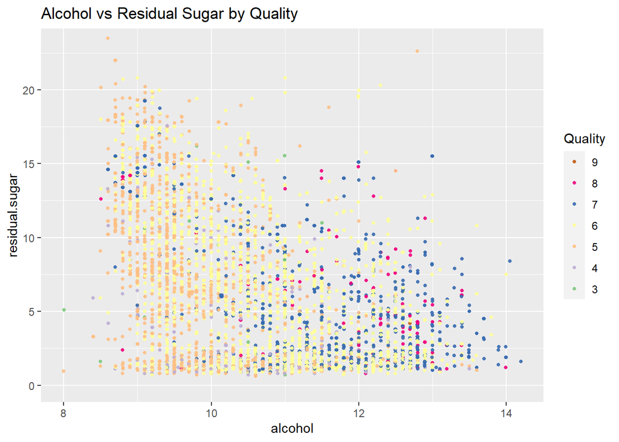

Visualization showing residual sugar, despite being highly correlated to density, does not impact quality rating as much as density.

### Residual Sugar vs Density by Quality

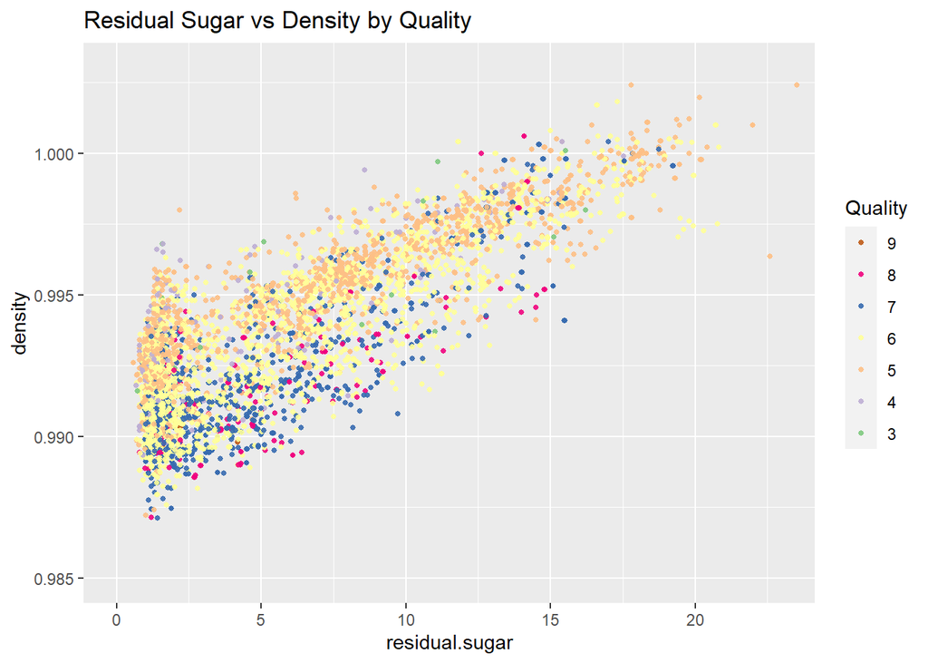

Visualization depicting the divide that density causes on quality even as the amount of residual sugar increases.

# Multivariate Analysis

investigation. Were there features that strengthened each other in terms of  
looking at your feature(s) of interest?

The biggest impact to quality is alcohol and density. The plots showed that as alcohol increases so does quality.

### Were there any interesting or surprising interactions between features?

It was interesting seeing visually how much alcohol will dominate the quality rating even if density is slightly increased.

# Final Plots and Summary

### Plot One: Quality vs Alcohol

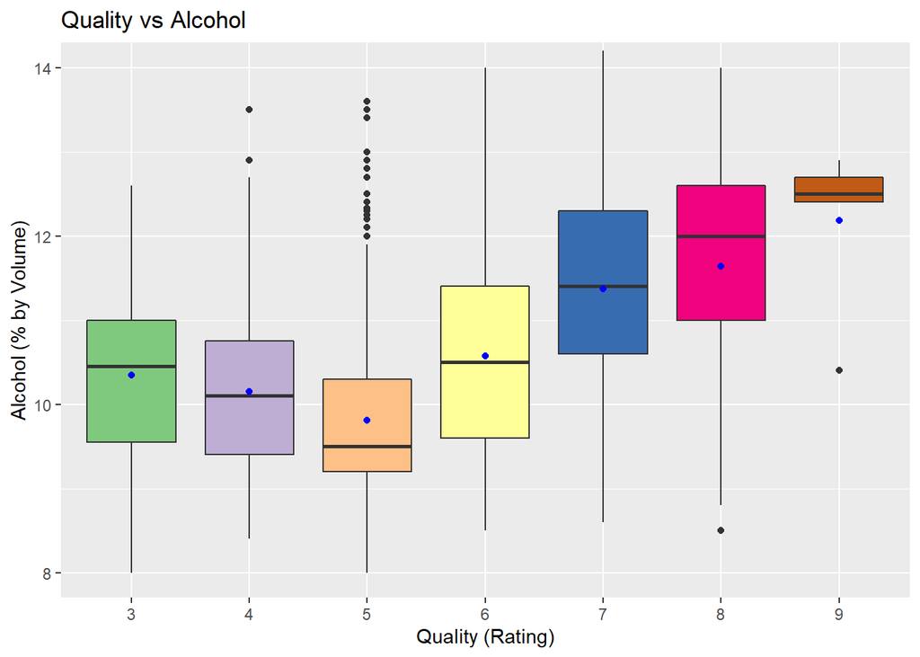

### Description One

Wines with a higher alcohol percentage have a higher quality rating. Therefore, increases the alcohol percentage in your wine will significantly increase the chance of getting a high wine rating.

### Plot Two: Quality vs Density

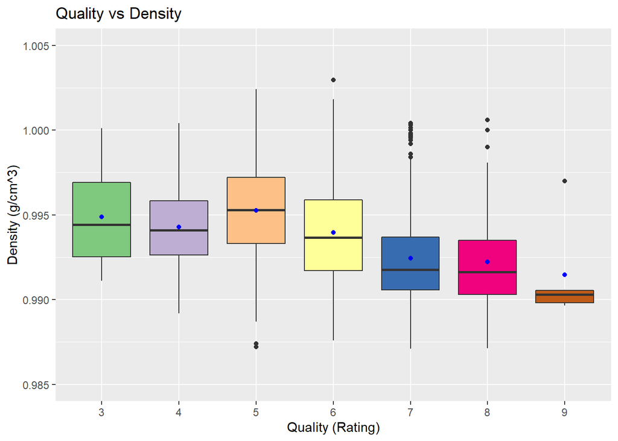

### Description Two

Wines with a higher density have a lower quality rating. Since highly rate wines are so rare, though it is only a small negative correlation, it’s impact is not something to be overlooked.

### Plot Three: Alcohol vs Density by Quality

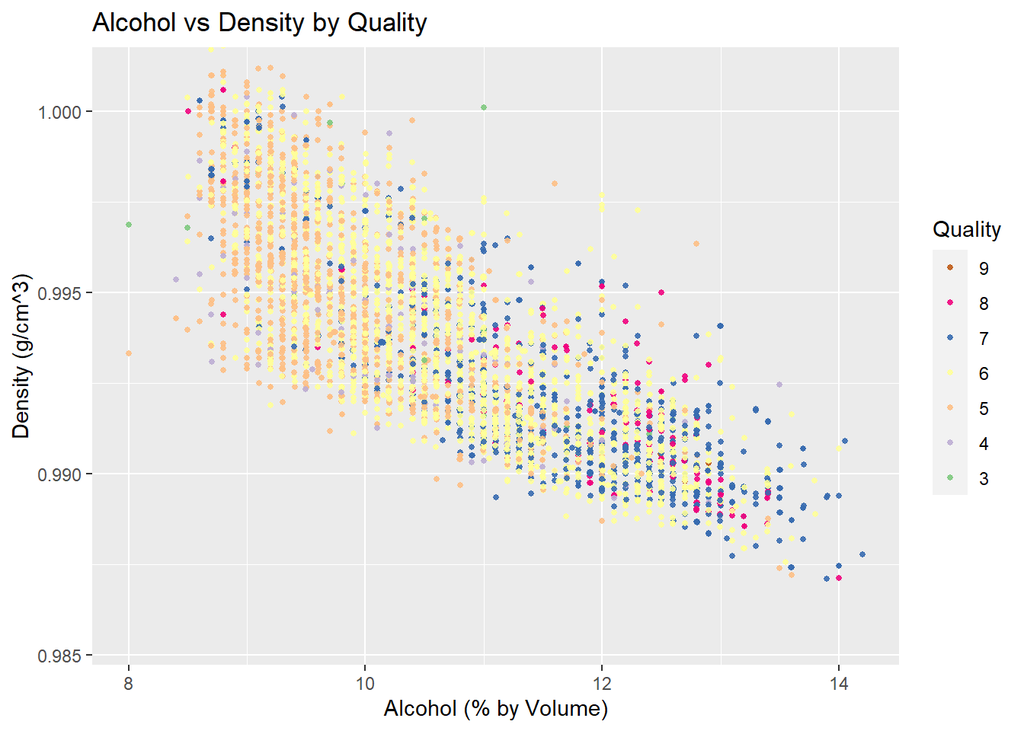

### Description Three

The two largest correlations to quality are summarized in this plot. Higher quality wines have a high alcohol percentage and a lower density.

# Reflection

The white wine data contains information on 4,898 different white wine samples across 13 variables from around 2007. I started by examining the main feature variable, quality. This lead me to become curious about what made a high quality wine. To answer my curiosity, I examined each wine attribute in the data set. From there, I found which attributes correlated with quality and other attributes. Finally, I explored the correlations against each other by quality. By doing this, I was able to explore the wine samples against many variables.